# Discussion 2

Wenyu Zhu

2020/6/24

# Step 3: Observed data & link to causal model.

**1. Specify the observed data.**

According to the question, we observe a sample of size n of random variable $O=(W, A, Y) \sim P^*$, which are independent, identically distributed (i.i.d). The observed data is a subset of X, which are generated by a system compatible with our structural causal model.

**2. What notation do we use to refer to the distribution of the observed data?**

Since we knew the distribution of U and the functions F, we would know the distribution of O , which is $O=(W, A, Y)\sim P$. The distribution of the background variables $P^*$ and the structural equations F identify the distribution of the observed data O.

**3. What is the link between the structural causal model (SCM) and the observed data?**

SCM:

- Endogenous nodes: $X =(W, A, Y)$
- Background (exogenous) variables: $U=(U_W,U_{A},U_{Y})\sim \mathrm{P}^*$
- Structural equations $F$:

$$\begin{align*}
W& \leftarrow f_{W}(U_{W})\\
A& \leftarrow f_A(W, U_A)\\
Y& \leftarrow f_{Y}(W, A, U_{Y})
\end{align*}$$

We know the observed data O, which is a subset of X, were generated by a system compatible with our structural causal model. The distribution of the background variables $P^*$ and the structural equations F identify the distribution of the observed data O.

Since we knew the distribution of U and the functions F, we would know the distribution of O , which is $O=(W, A, Y)\sim P$. Therefore, the causal model has implications for the distribution of O. These implications are testable.

**4. What is the statistical model? Does the SCM place any restrictions on it?**

Non-parametric statistical model:

$Y_1 \leftarrow f_{Y}(W, 1, U_{Y})$

$Y_0 \leftarrow f_{Y}(W, 0, U_{Y})$

$(Y_1,Y_0) \sim \mathrm{P}^*$

The SCM is a non-parametric model on the distribution of these counterfactuals.

There is no exclusion restriction and independence restrictions on it.

# Steps 4-5: Identifiability & Committing to a statistical estimand

**5. Assess the identifiability of $\theta^*$ using the back-door criterion.**

DAG:

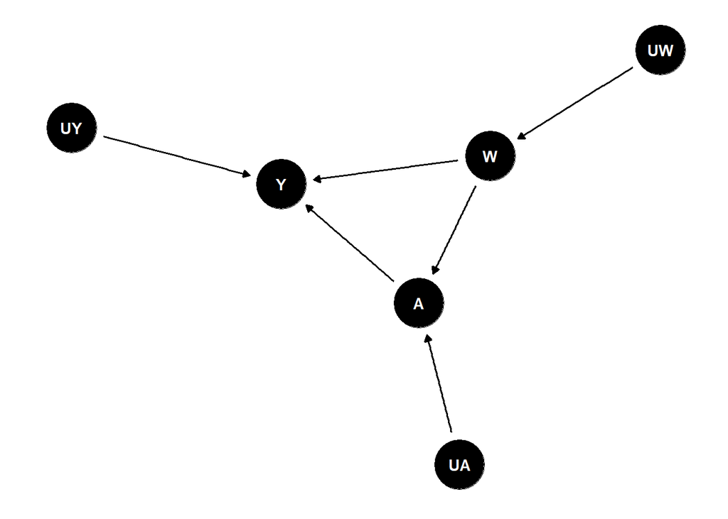

```r
library(ggdag)
plot1 <- dagify(Y ~ W+ A + UY,
                A ~ W + UA,
                W ~ UW,
                exposure = "A",
                outcome = "Y")
ggdag(plot1)+ theme_dag_blank()
```

**6. If not identified, under what assumptions would it be? Are some of these sets of additional assumptions more plausible than others?**

Under some independence assumptions, it can be identified.

$Y_a \indep A|W$ is satisfied when:

$U_A \indep U_Y$ and $U_A \indep U_W$ or/and $U_Y \indep U_W$ in total 3 ways.

**7. Are there additional measurements you could make so that the needed identifiability assumptions are more plausible?**

**8. Specify the target parameter of the observed data distribution (i.e. the statistical estimand).**

The target parameter of the observed data distribution (the statistical estimand):

$$\begin{align*}
\theta &=E[E(Y|A=1,W)-E(Y|A=0,W)]\\
&= \sum_{w}[E(Y|A=1,w)-E(Y|A=0,w)]P(w)
\end{align*}$$

**9. In your opinion, what is the relevant positivity assumption? Are you concerned about violations of the positivity assumption in your study?**

Relevent positive assumption:

Positivity assumes that everyone has some chance of getting the treatment. If there is no chance that a given population would receive the intervention, then we can measure the average treatment effect across all patient types X. If this does occur, one would need to exclude these patient subgroups where positivity is violated from the analysis.

$min_{a \in \{0,1\}}P(A=a|W=w)>0$

For all $w$ which $P(W)>0$

There might be some violations of the positivity assuption in the study. Because W = {smoking, comorbidities, body fat}, A = {energy expenditure}, it might be few data when W is under the condition of smoking, having comorbidities and high body fat and A is high energy expenditure(A=1).

**10. Suppose the investigators assume no unmeasured common causes of $(W,A,Y)$ is this necessary for identifiability? Is it sufficient?**

It is necessary for identifiability. It is not sufficient, because if there are some measured common causes of $(W,A,Y)$, the independence assuption of $U_A \indep U_Y$ and $U_A \indep U_W$ or/and $U_Y \indep U_W$ might be violated, which may violate the identifiability.